# *detlimitr*

### An introduction to the detlimitr package

The *detlimitr* (estimating **det**ection **limit**s using **R**) package contains functions for use with calibration data in analytical chemistry,

The detection limit is an important figure of merit in chemical analysis. It is also known as the lower limit of detection, or LOD (limit of detection), and can be defined as the lowest quantity of a substance that can be distinguished from the absence of that substance (a blank value) with a stated confidence level (generally 99%).

If required, the *detlimiter* package can be downloaded using

```
#install.packages("devtools")
devtools::install_github("peterjwatkins/detlimitr", force=TRUE)
```

Some example code:

```r
library(detlimitr)
data(mtbe)
head(mtbe)
```

```
## # A tibble: 6 × 2
##       x     y
##   <dbl> <dbl>
## 1   1    1005
## 2   1    1003
## 3   1     998
## 4   1     993
## 5   2.9  2551
## 6   2.9  2548
```

```r
summaryDL(mtbe)
```

```
## Miller 1.1
## Vogelsang-Hadrich 0.7
## chemCal 1.3
## Hubaux-Vos 1.7
```

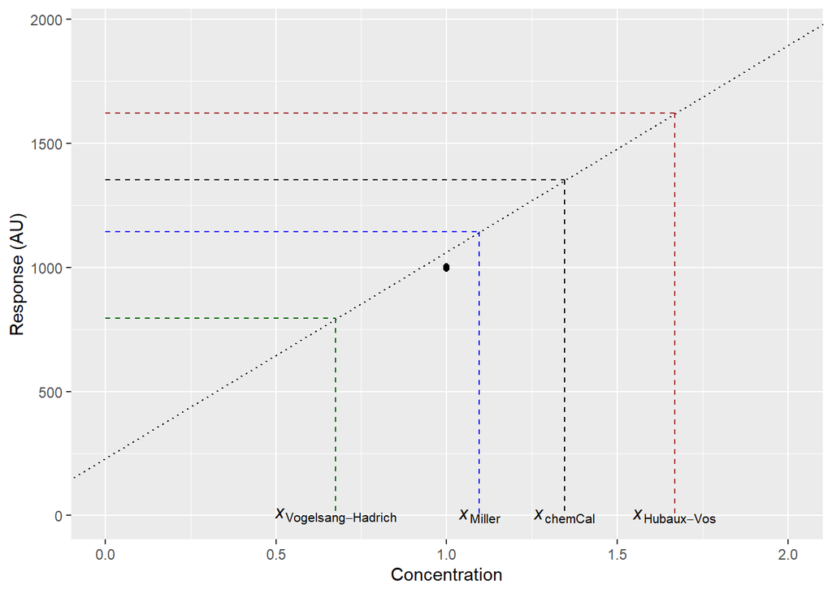

```r
#tabulateDL(mtbe)
plotDL(mtbe)
```

The graph resulting from *plotDL* has generic labels on the plot. This can be changed using appropriate *ggplot2* commands. For example,

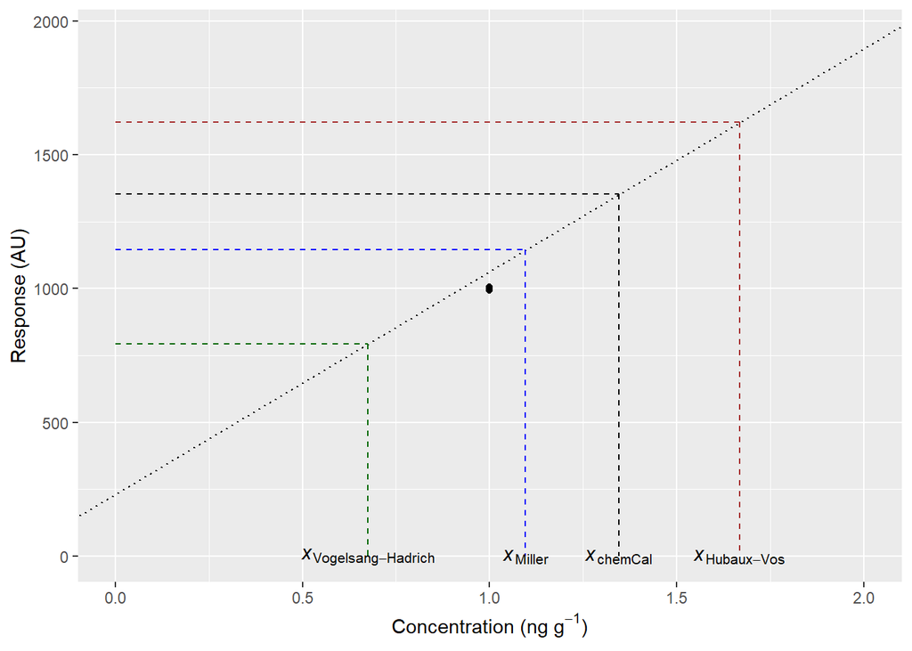

```r
p <- plotDL(mtbe)
p +
  ggplot2::xlab(expression(paste("Concentration (ng", " ", "g" ^ {-1}, ")")))
```

**References**

1. J.C. Miller and J.N. Miller (1993), “Statistics for Analytical Chemistry”, 3rd ed., Prentice-Hall.
2. J. Vogelgesang and J. Hädrich (1998), Accred. Qual. Assur., 3:242-255.
3. A. Hubaux and G. Vos (1970), Anal. Chem., 42:849-855 & D.T. O’Neill, E.A. Rochette and P.J. Ramsay, (2002), Anal. Chem., 74:5907-5911
4. J. Ranke (2018), chemCal: Calibration Functions for Analytical Chemistry, https://CRAN.R-project.org/package=chemCal